**Duy Ha**

# League of Legends Data Analysis: Should You Surrender at 15 10?

## Context and Motivation

League of Legends (LoL) is a strategic multiplayer game published by Riot Games in which two opposing teams face off in a five-versus-five fashion. In each match, a team's ultimate win condition is to destroy the enemy team's Nexus; global objectives, such as defensive structures and neutral monsters, exist as additional complexities to help drive a team to victory. Each player assumes the role of a "champion" with unique abilities. Over the several years of playing this wonderful game, I have developed an intuition for determining each match's victor, but this 'sixth sense' of mine only kicks in at around 25 minutes after matchstart. What if we were able to determine a winner through solely data? The earliest point in which a team can surrender is 15 minutes into the match, so the ability to know which team wins beforehand will be extremely beneficial for all players. Although the act of surrendering may be looked down upon, there are several reasons a team may opt to forfeit that do not necessarily suggest a weak-willed composure.

## Dataset and Objective

The dataset we will be using is **high_diamond_ranked_10min** (https://www.kaggle.com/datasets/bobbyscience/league-of-legends-diamond-ranked-games-10-min) with 10K observations and 40 features. The observations represent a LoL match (keyed with a gameID) and are labeled with a winner (blueWin 0 or 1). Each team has a set of 19 team-dependent features for a total of 38 for each match. We are only considering Diamond-ranked solo queue games, meaning that the 10 players in a match have roughly equal amount of experience and game knowledge. These values are collected after the first 10 minutes, thus giving five minutes to contemplate a forfeit; although, a lot can happen within five minutes! We are only considering a match's global variables, so this analysis will be independent of champions the players pick. Since champions are often patched and revamped, considering them will make this notebook quickly outdated. There are also no missing values.

**The objective of this notebook is to use supervised machine learning and feature engineering to predict which game variables correlate to a win.**

**GLOSSARY** *(from the dataset description)*

- Warding totem: An item that a player can put on the map to reveal the nearby area. Very useful for map/objectives control.
- Minions: NPC that belong to both teams. They give gold when killed by players.
- Jungle minions: NPC that belong to NO TEAM. They give gold and buffs when killed by players.
- Elite monsters: Monsters with high hp/damage that give a massive bonus (gold/XP/stats) when killed by a team.
- Dragons: Elite monster which gives team bonus when killed. The 4th dragon killed by a team gives a massive stats bonus. The 5th dragon (Elder Dragon) offers a huge advantage to the team.
- Herald: Elite monster which gives stats bonus when killed by the player. It helps to push a lane and destroys structures.
- Towers: Structures you have to destroy to reach the enemy Nexus. They give gold.
- Level: Champion level. Start at 1. Max is 18.

## Initialization

```python
from sklearnex import patch_sklearn
patch_sklearn()

import pandas as pd
import numpy as np
import matplotlib.pyplot as plt
import seaborn as sns
import tensorflow as tf

from sklearn.preprocessing import StandardScaler
from sklearn.model_selection import train_test_split, cross_val_score
from sklearn.model_selection import RepeatedStratifiedKFold
from sklearn.model_selection import GridSearchCV
from sklearn.metrics import accuracy_score, ConfusionMatrixDisplay
from sklearn.feature_selection import SelectFromModel

from sklearn.decomposition import PCA
from sklearn.manifold import TSNE
from sklearn.ensemble import GradientBoostingClassifier, RandomForestClassifier
from sklearn.linear_model import LogisticRegression



from matplotlib import pyplot as plt

from sklearn.model_selection import KFold

from tensorflow.keras.models import Model
from tensorflow.keras.layers import Input, Dense, Flatten
from tensorflow.keras.optimizers import Adam
from tensorflow.keras.callbacks import EarlyStopping


# Testing and Debugging
import warnings
warnings.filterwarnings('ignore')
tf.debugging.set_log_device_placement(False)
tf.config.list_physical_devices('GPU')
```

```
Intel(R) Extension for Scikit-learn* enabled (https://github.com/intel/scikit-learn-intelex)
```

```
[PhysicalDevice(name='/physical_device:GPU:0', device_type='GPU')]
```

### Data Preparation

```python
# Import data
df = pd.read_csv('data/high_diamond_ranked_10min.csv')
# Preview data
df.head()

# Prepare data for Unsupervised Learning

# Drop unnecessary columns
data = df.drop(['gameId', 'blueWins'], axis=1)

feature_labels = np.array(data.columns)

# Standardize features
data = StandardScaler().fit_transform(data)

# Get labels for plotting
ylabels = df['blueWins']

# Preview features and column data types
df.info()
```

```
<class 'pandas.core.frame.DataFrame'>
RangeIndex: 9879 entries, 0 to 9878
Data columns (total 40 columns):
 #   Column                        Non-Null Count  Dtype
---  ------                        --------------  -----
 0   gameId                        9879 non-null   int64
 1   blueWins                      9879 non-null   int64
 2   blueWardsPlaced               9879 non-null   int64
 3   blueWardsDestroyed            9879 non-null   int64
 4   blueFirstBlood                9879 non-null   int64
 5   blueKills                     9879 non-null   int64
 6   blueDeaths                    9879 non-null   int64
 7   blueAssists                   9879 non-null   int64
 8   blueEliteMonsters             9879 non-null   int64
 9   blueDragons                   9879 non-null   int64
```

[output cut: 32 more lines]

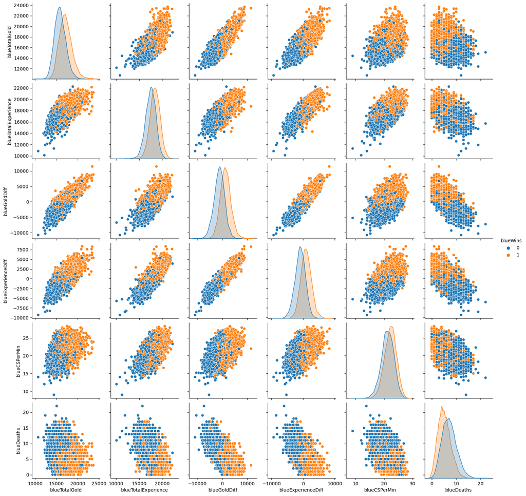

```python
# Visualize some columns
sns.pairplot(df[['blueTotalGold',
                'blueTotalExperience',
                'blueGoldDiff',
                'blueExperienceDiff',
                'blueCSPerMin',
                'blueDeaths',
                'blueWins']], hue='blueWins')
plt.show()
```

# Unsupervised Visualization

Before building our ML models, we will visualize the data using several unsupervised techniques

```python
# Preparation

# Helper function for plotting PCA bi_plot with feature vectors
def component_biplot(score, coeff, ylabels, feature_labels=None, feature_num=-1):
    xs = score[:,0]
    ys = score[:,1]

    scalex = 1.0/(xs.max() - xs.min())
    scaley = 1.0/(ys.max() - ys.min())
    scatter = plt.scatter(xs * scalex,ys * scaley, c = ylabels, edgecolors='none', alpha=0.5,
            cmap=plt.cm.get_cmap('Spectral'))

    plt.legend(handles=scatter.legend_elements()[0], labels=['Blue Loss', 'Blue Wins'])

    if feature_num == -1:
        n = coeff.shape[0]
    else:
        n = feature_num

    for i in range(n):
        plt.arrow(0, 0, coeff[i,0], coeff[i,1],color = 'b', alpha = 0.5)
        if feature_labels is None:
            plt.text(coeff[i,0]* 1.15, coeff[i,1] * 1.15, "Var"+str(i+1), color = 'black', ha = 'center', va = 'center')
        else:
            plt.text(coeff[i,0]* 1.15, coeff[i,1] * 1.15, feature_labels[i], color = 'black', ha = 'center', va = 'center')
```

## PCA

We will visualize our data in 2-dimensions by constructing a biplot of the top 2 PCAs. Additionally, PCA will help us determine whether or not to perform dimensionality reduction when we train our ML models

```python
# PCA
pca = PCA(2)
projected = pca.fit_transform(data)

# Print out explained variance
print('Cumulative explained variation for 2 principal components: {} = {}%'.format(pca.explained_variance_ratio_, np.sum(pca.explained_variance_ratio_*100)))
```

```
Cumulative explained variation for 2 principal components: [0.32836652 0.12140505] = 44.97715633054876%
```

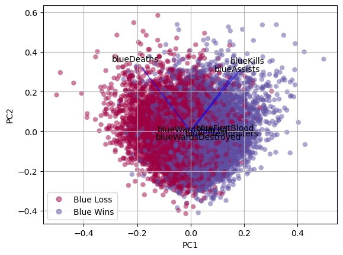

```python
# Plot PCA with 7 feature vectors

plt.xlabel("PC1")
plt.ylabel("PC2")
plt.grid()

component_biplot(projected[:, 0:2], np.transpose(pca.components_[0:2, :]), ylabels=ylabels, feature_labels=feature_labels, feature_num=7)
plt.show()
```

When we begin fitting our ML models, we want to choose the number of principal components that explain 90% of our data dispersion. We use the PCA fit's attribute explained_variance_ratio to determine the number of principal components that we must retain. We saw earlier that 2 principal components explain roughly 45% of the variance. We see below that the number of components that will get us to 90% is 14. This means that we will retain 14 principal components, reducing the dimensionality from 38 to 14!

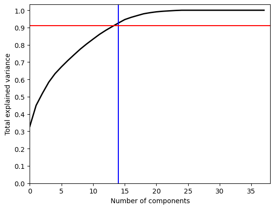

```python
# Plot total explained variancce vs number of components
pca = PCA().fit(data)

# We see from the raw plot that around 14 is 90% explained variance, we use this to dial in at n=14
n = 14

plt.plot(np.cumsum(pca.explained_variance_ratio_), color='k', lw=2)
plt.xlabel('Number of components')
plt.ylabel('Total explained variance')
plt.xlim(0, 38)
plt.yticks(np.arange(0, 1.1, 0.1))
plt.axvline(n, c='b')
plt.axhline(0.91, c='r')
plt.show()
```

## Can we separate this any further?

We apply tSNE with an optimal PCA with 90% explained variance

```python
# Apply TSNE to PCA components

# Create PCA Base
pca_90 = PCA(n_components=14)
pca_result_90 = pca_90.fit_transform(data)

print('Cumulative explained variation for 14 principal components: {}'.format(np.sum(pca_90.explained_variance_ratio_)))

tsne = TSNE(n_components=2, n_iter=300)
tsne_pca_results = tsne.fit_transform(pca_result_90)
```

```
Cumulative explained variation for 14 principal components: 0.9051059835980786
```

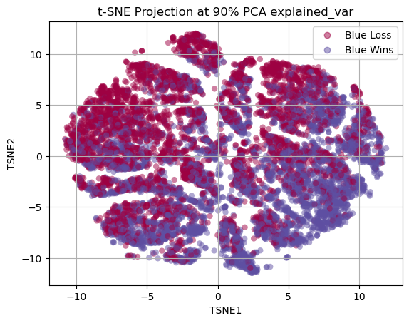

```python
# Plot 2D array of TSNE component1 vs. component2
scatter = plt.scatter(tsne_pca_results[:, 0], tsne_pca_results[:, 1],
            c=ylabels, edgecolors='none', alpha=0.5,
            cmap=plt.cm.get_cmap('Spectral'))

plt.xlabel('TSNE1')
plt.ylabel('TSNE2')
plt.grid()
plt.legend(handles=scatter.legend_elements()[0], labels=['Blue Loss', 'Blue Wins'])
plt.title("t-SNE Projection at 90% PCA explained_var")
```

# Training and Evaluating Machine Learning Models

```python
# Dictionary to store model keys and accuracy values for final reflection
model_dict = {}

# Construct our observation matrix X
X = df.drop(['blueWins', 'gameId'], axis=1)
# Construct label vector y
y = df['blueWins']

# Perform stratified 80/20 training and testing split
X_train, X_test, y_train, y_test = train_test_split(X, y, test_size=0.2, stratify=y, random_state=1)

print("Shape of training data: ", np.shape(X_train))
print("Shape of test data: ", np.shape(X_test))
```

```
Shape of training data:  (7903, 38)
Shape of test data:  (1976, 38)
```

```python
# Define an API for our helper functions

# Define validation method for models using cross-validation
def evaluate_model(model, X, y, n_splits=10, n_repeats=3):
    # define the evaluation procedure
    cv = RepeatedStratifiedKFold(n_splits=n_splits, n_repeats=n_repeats, random_state=1)
    # evaluate the model and collect the results
    scores = cross_val_score(model, X, y, scoring='accuracy', cv=cv, n_jobs=-1)
    return scores

# Define a method for gridsearch for hyperparameters with accuracy scoring, uses CV
def hyper_param_tune(X_train, y_train, model, grid, cv):
    grid_search = GridSearchCV(estimator=model, param_grid=grid, n_jobs=-1, cv=cv, return_train_score=True, scoring='accuracy')
    # execute the grid search
    grid_result = grid_search.fit(X_train, y_train)
    # summarize the best score and configuration
    print("Best: %f using %s" % (grid_result.best_score_, grid_result.best_params_))
    # summarize all scores that were evaluated
    means = grid_result.cv_results_['mean_test_score']
    stds = grid_result.cv_results_['std_test_score']
    params = grid_result.cv_results_['params']
    for mean, stdev, param in zip(means, stds, params):
        print("%f (%f) with: %r" % (mean, stdev, param))

    return grid_result

# Define a method for plotting CV average vs. param from grid search
def plot_grid_search(grid_params, cv_results):
    fig, axes = plt.subplots(1, len(grid_params),
                            figsize = (3*len(grid_params), 5),
                            sharey='row')
    axes[0].set_ylabel("Score", fontsize=25)

    res_label = ['mean_test_score',
            'mean_train_score']

    for idx, (param_name, param_range) in enumerate(grid_params.items()):
        grouped_df = cv_results.groupby(f'param_{param_name}')[res_label]\
            .agg({'mean_train_score': 'mean',
                'mean_test_score': 'mean'})

        # previous_group = df.groupby(f'param_{param_name}')[res_label]
        axes[idx].set_xlabel(param_name, fontsize=15)
        axes[idx].set_ylim(.4, 1.1)
        axes[idx].plot(param_range, grouped_df['mean_train_score'], label="Training score",
                    color="darkorange", lw=2, marker='o')
        axes[idx].fill_between(param_range, grouped_df['mean_train_score'],
                        grouped_df['mean_train_score'], alpha=0.2,
                        color="darkorange", lw=2)
        axes[idx].plot(param_range, grouped_df['mean_test_score'], label="Cross-validation score",
                    color="navy", lw=2, marker='o')
        axes[idx].fill_between(param_range, grouped_df['mean_test_score'],
                        grouped_df['mean_test_score'], alpha=0.2,
                        color="navy", lw=2)

    handles, labels = axes[0].get_legend_handles_labels()
    fig.suptitle('Validation curves', fontsize=15)
    fig.legend(handles, labels, loc=8, ncol=2, fontsize=15)

    fig.subplots_adjust(bottom=0.25, top=0.85)

# Define method for summarizing
def summarize_performance(y_pred, fitted_model, display_matrix=True):
    acc = accuracy_score(y_pred, y_test)

    # print summary
    print('Accuracy: = %.3f' % (np.mean(acc)*100))
    if display_matrix:
        ConfusionMatrixDisplay.from_estimator(fitted_model, X_test, y_test)
    return np.mean(acc)*100
```

## Logistic Regression

I chose Logistic Regression as a primary base for other model comparisons because of its popularity and ubiquitous use in binary classification problems. Additionally, the ability to tune Logistic Regression with different penalty can help me discern the significance of feature scaling, especially for the case with the LASSO penalty. Although a Logistic Regression with LASSO penalty could be a useful tool for feature selection, it would potentially overfit the features because the model is trained for prediction (and thus, not interpretability).

We use saga solver since we want to validate with different penalties and our dataset is a decent size.

```python
# Logistic Regression
model = LogisticRegression(solver='saga')

grid = dict()
grid['C'] = np.logspace(-5, 5, 10)
grid['penalty'] = ['l1', 'l2']

cv = RepeatedStratifiedKFold(n_splits=5, n_repeats=5, random_state=1)

grid_result = hyper_param_tune(X_train=X_train, y_train=y_train, model=model, grid=grid, cv=cv)
```

```
Best: 0.730178 using {'C': 1e-05, 'penalty': 'l1'}
0.730178 (0.008975) with: {'C': 1e-05, 'penalty': 'l1'}
0.729748 (0.008604) with: {'C': 1e-05, 'penalty': 'l2'}
0.730052 (0.008131) with: {'C': 0.0001291549665014884, 'penalty': 'l1'}
0.729748 (0.008604) with: {'C': 0.0001291549665014884, 'penalty': 'l2'}
0.729900 (0.008571) with: {'C': 0.0016681005372000592, 'penalty': 'l1'}
0.729748 (0.008604) with: {'C': 0.0016681005372000592, 'penalty': 'l2'}
0.729748 (0.008590) with: {'C': 0.021544346900318846, 'penalty': 'l1'}
0.729748 (0.008604) with: {'C': 0.021544346900318846, 'penalty': 'l2'}
0.729723 (0.008570) with: {'C': 0.2782559402207126, 'penalty': 'l1'}
0.729748 (0.008604) with: {'C': 0.2782559402207126, 'penalty': 'l2'}
0.729748 (0.008604) with: {'C': 3.593813663804626, 'penalty': 'l1'}
0.729748 (0.008604) with: {'C': 3.593813663804626, 'penalty': 'l2'}
0.729723 (0.008570) with: {'C': 46.41588833612782, 'penalty': 'l1'}
0.729723 (0.008570) with: {'C': 46.41588833612782, 'penalty': 'l2'}
0.729748 (0.008604) with: {'C': 599.4842503189421, 'penalty': 'l1'}
0.729748 (0.008604) with: {'C': 599.4842503189421, 'penalty': 'l2'}
0.729723 (0.008570) with: {'C': 7742.636826811277, 'penalty': 'l1'}
0.729723 (0.008570) with: {'C': 7742.636826811277, 'penalty': 'l2'}
0.729748 (0.008604) with: {'C': 100000.0, 'penalty': 'l1'}
0.729748 (0.008604) with: {'C': 100000.0, 'penalty': 'l2'}
```

```
[1.00000000e-05 1.29154967e-04 1.66810054e-03 2.15443469e-02
 2.78255940e-01 3.59381366e+00 4.64158883e+01 5.99484250e+02
 7.74263683e+03 1.00000000e+05]
```

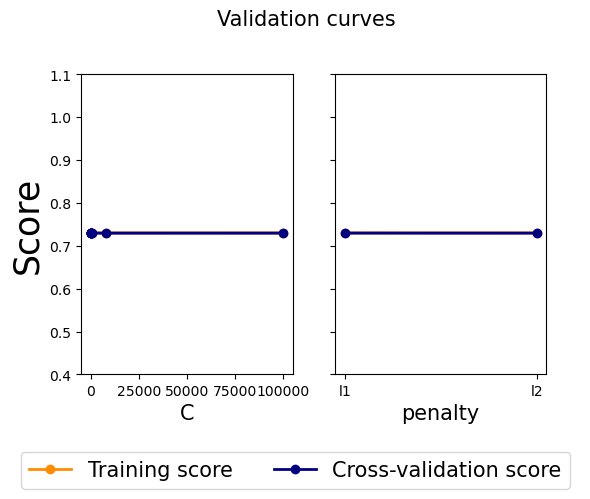

```python
# Plot CV Accuracy vs. n_estimators w/ learning_rate curves
print(np.logspace(-5, 5, 10))
plot_grid_search(cv_results=pd.DataFrame(grid_result.cv_results_),
                grid_params=grid)
```

```
Accuracy: = 71.457
```

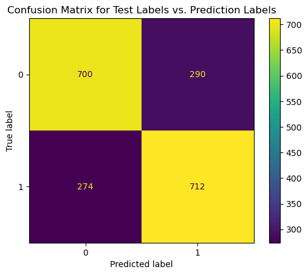

```python
# Construct model on tuned hyperparameters
lr_params = grid_result.best_params_

lr = LogisticRegression(solver='saga',
                        C=lr_params['C'],
                        penalty=lr_params['penalty'])
# Fit tuned model to training
lr.fit(X_train, y_train)

# Validate our tuned model on the test set
y_pred = lr.predict(X_test)

# Get test accuracy of tuned model
lr_acc = summarize_performance(y_pred, lr)
model_dict['Logistic Regression'] = lr_acc
plt.title("Confusion Matrix for Test Labels vs. Prediction Labels")
plt.show()
```

## Gradient Boosting

We use Gradient Boosting for this classification problem with log-loss as our default loss function because we would like to represent the model in similar fashion as Logistic Regression. With Gradient Boosting, I want to see if the overall prediction error is improved by combining with several estimators. Additionally, using these estimators for Gradient Boosting can help infer feature importance of this dataset.

```python
# Gradient Boosting
model = GradientBoostingClassifier()

grid = dict()
grid['n_estimators'] = [10, 50, 200]
grid['learning_rate'] = [1.0, 0.1, 0.01]
grid['subsample'] = [0.5, 1.0] # <1.0 is Stochastic Gradient Boosting
grid['max_depth'] = [3, 9]

cv = RepeatedStratifiedKFold(n_splits=5, n_repeats=5, random_state=1)

grid_result = hyper_param_tune(X_train=X_train, y_train=y_train, model=model, grid=grid, cv=cv)
```

```
Best: 0.732431 using {'learning_rate': 0.01, 'max_depth': 3, 'n_estimators': 200, 'subsample': 1.0}
0.706416 (0.011057) with: {'learning_rate': 1.0, 'max_depth': 3, 'n_estimators': 10, 'subsample': 0.5}
0.714590 (0.010312) with: {'learning_rate': 1.0, 'max_depth': 3, 'n_estimators': 10, 'subsample': 1.0}
0.671695 (0.010198) with: {'learning_rate': 1.0, 'max_depth': 3, 'n_estimators': 50, 'subsample': 0.5}
0.687714 (0.012037) with: {'learning_rate': 1.0, 'max_depth': 3, 'n_estimators': 50, 'subsample': 1.0}
0.644616 (0.010057) with: {'learning_rate': 1.0, 'max_depth': 3, 'n_estimators': 200, 'subsample': 0.5}
0.664684 (0.007112) with: {'learning_rate': 1.0, 'max_depth': 3, 'n_estimators': 200, 'subsample': 1.0}
0.643705 (0.008592) with: {'learning_rate': 1.0, 'max_depth': 9, 'n_estimators': 10, 'subsample': 0.5}
0.663116 (0.008315) with: {'learning_rate': 1.0, 'max_depth': 9, 'n_estimators': 10, 'subsample': 1.0}
0.627788 (0.013986) with: {'learning_rate': 1.0, 'max_depth': 9, 'n_estimators': 50, 'subsample': 0.5}
0.682425 (0.009698) with: {'learning_rate': 1.0, 'max_depth': 9, 'n_estimators': 50, 'subsample': 1.0}
0.547134 (0.034087) with: {'learning_rate': 1.0, 'max_depth': 9, 'n_estimators': 200, 'subsample': 0.5}
0.700696 (0.009405) with: {'learning_rate': 1.0, 'max_depth': 9, 'n_estimators': 200, 'subsample': 1.0}
0.731292 (0.008129) with: {'learning_rate': 0.1, 'max_depth': 3, 'n_estimators': 10, 'subsample': 0.5}
0.731191 (0.008967) with: {'learning_rate': 0.1, 'max_depth': 3, 'n_estimators': 10, 'subsample': 1.0}
0.729040 (0.008484) with: {'learning_rate': 0.1, 'max_depth': 3, 'n_estimators': 50, 'subsample': 0.5}
0.731571 (0.008916) with: {'learning_rate': 0.1, 'max_depth': 3, 'n_estimators': 50, 'subsample': 1.0}
0.721295 (0.009236) with: {'learning_rate': 0.1, 'max_depth': 3, 'n_estimators': 200, 'subsample': 0.5}
0.726661 (0.008479) with: {'learning_rate': 0.1, 'max_depth': 3, 'n_estimators': 200, 'subsample': 1.0}
0.706592 (0.012073) with: {'learning_rate': 0.1, 'max_depth': 9, 'n_estimators': 10, 'subsample': 0.5}
0.707985 (0.009516) with: {'learning_rate': 0.1, 'max_depth': 9, 'n_estimators': 10, 'subsample': 1.0}
0.708566 (0.008030) with: {'learning_rate': 0.1, 'max_depth': 9, 'n_estimators': 50, 'subsample': 0.5}
0.712414 (0.009823) with: {'learning_rate': 0.1, 'max_depth': 9, 'n_estimators': 50, 'subsample': 1.0}
0.707934 (0.009405) with: {'learning_rate': 0.1, 'max_depth': 9, 'n_estimators': 200, 'subsample': 0.5}
0.712969 (0.010209) with: {'learning_rate': 0.1, 'max_depth': 9, 'n_estimators': 200, 'subsample': 1.0}
0.728053 (0.009266) with: {'learning_rate': 0.01, 'max_depth': 3, 'n_estimators': 10, 'subsample': 0.5}
0.722511 (0.009124) with: {'learning_rate': 0.01, 'max_depth': 3, 'n_estimators': 10, 'subsample': 1.0}
0.730381 (0.007635) with: {'learning_rate': 0.01, 'max_depth': 3, 'n_estimators': 50, 'subsample': 0.5}
0.727977 (0.008760) with: {'learning_rate': 0.01, 'max_depth': 3, 'n_estimators': 50, 'subsample': 1.0}
0.731672 (0.009244) with: {'learning_rate': 0.01, 'max_depth': 3, 'n_estimators': 200, 'subsample': 0.5}
0.732431 (0.008217) with: {'learning_rate': 0.01, 'max_depth': 3, 'n_estimators': 200, 'subsample': 1.0}
0.715754 (0.008511) with: {'learning_rate': 0.01, 'max_depth': 9, 'n_estimators': 10, 'subsample': 0.5}
0.696115 (0.011735) with: {'learning_rate': 0.01, 'max_depth': 9, 'n_estimators': 10, 'subsample': 1.0}
0.724864 (0.010371) with: {'learning_rate': 0.01, 'max_depth': 9, 'n_estimators': 50, 'subsample': 0.5}
0.706390 (0.008458) with: {'learning_rate': 0.01, 'max_depth': 9, 'n_estimators': 50, 'subsample': 1.0}
0.724763 (0.008776) with: {'learning_rate': 0.01, 'max_depth': 9, 'n_estimators': 200, 'subsample': 0.5}
0.715753 (0.009614) with: {'learning_rate': 0.01, 'max_depth': 9, 'n_estimators': 200, 'subsample': 1.0}
```

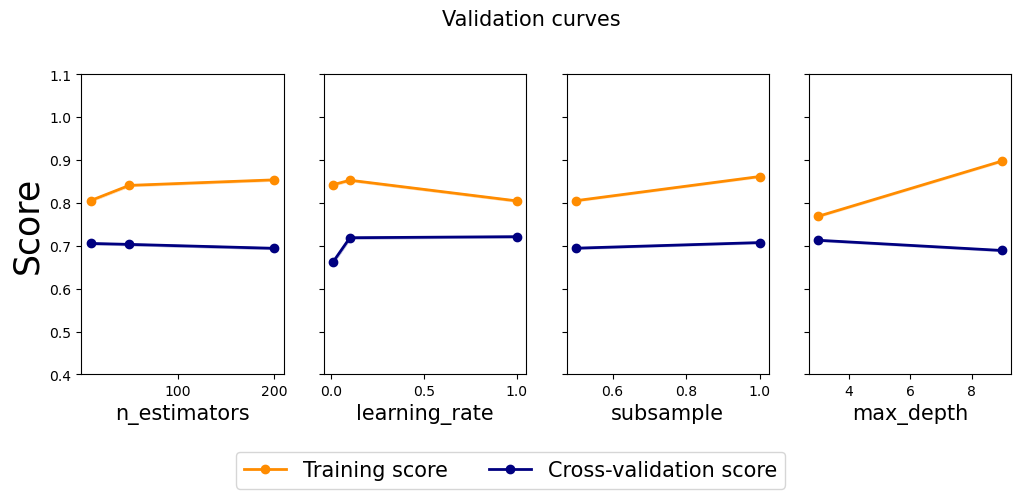

```python
# Plot CV Accuracy vs. n_estimators w/ learning_rate curves

plot_grid_search(cv_results=pd.DataFrame(grid_result.cv_results_),
                grid_params=grid)
```

```
Accuracy: = 72.318
```

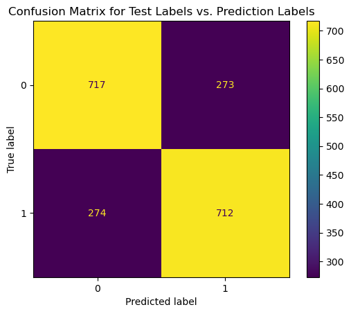

```python
# Construct model on tuned hyperparameters
gboost_params = grid_result.best_params_

gboost = GradientBoostingClassifier(n_estimators=gboost_params['n_estimators'],
                                    learning_rate=gboost_params['learning_rate'],
                                    max_depth=gboost_params['max_depth'],
                                    subsample=gboost_params['subsample'])
# Fit tuned model to training
gboost.fit(X_train, y_train)

# Validate our tuned model on the test set
y_pred = gboost.predict(X_test)

# Get test accuracy of tuned model
gboost_acc = summarize_performance(y_pred, gboost)
model_dict['Gradient Boosting Classifier'] = gboost_acc
plt.title("Confusion Matrix for Test Labels vs. Prediction Labels")
plt.show()
```

## Random Forest

Random Forest is primarily used as a more direct comparison to the above Gradient Boosting in order to see if the amount of estimators that yield the best accuracy for feature selection, since boosting usually uses significantly more trees than Random Forest due to shallowness of the optimal boosting model. Additionally, random forest could give us an extra layer of insight into feature importance.

```python
# Random Forest
model = RandomForestClassifier()

grid = dict()
grid['n_estimators'] = [10, 50, 500, 2000]
grid['min_samples_split'] = [2, 4, 8]
grid['max_depth'] = [3, 7, 9]

cv = RepeatedStratifiedKFold(n_splits=5, n_repeats=5, random_state=1)

grid_result = hyper_param_tune(X_train=X_train, y_train=y_train, model=model, grid=grid, cv=cv)
```

```
Best: 0.731773 using {'max_depth': 7, 'min_samples_split': 4, 'n_estimators': 500}
0.727573 (0.007496) with: {'max_depth': 3, 'min_samples_split': 2, 'n_estimators': 10}
0.729267 (0.008660) with: {'max_depth': 3, 'min_samples_split': 2, 'n_estimators': 50}
0.730609 (0.008492) with: {'max_depth': 3, 'min_samples_split': 2, 'n_estimators': 500}
0.730837 (0.008170) with: {'max_depth': 3, 'min_samples_split': 2, 'n_estimators': 2000}
0.726054 (0.008934) with: {'max_depth': 3, 'min_samples_split': 4, 'n_estimators': 10}
0.728736 (0.007171) with: {'max_depth': 3, 'min_samples_split': 4, 'n_estimators': 50}
0.730964 (0.008480) with: {'max_depth': 3, 'min_samples_split': 4, 'n_estimators': 500}
0.730761 (0.008385) with: {'max_depth': 3, 'min_samples_split': 4, 'n_estimators': 2000}
0.728559 (0.007468) with: {'max_depth': 3, 'min_samples_split': 8, 'n_estimators': 10}
0.728635 (0.008301) with: {'max_depth': 3, 'min_samples_split': 8, 'n_estimators': 50}
0.730938 (0.008017) with: {'max_depth': 3, 'min_samples_split': 8, 'n_estimators': 500}
0.730685 (0.008215) with: {'max_depth': 3, 'min_samples_split': 8, 'n_estimators': 2000}
0.724105 (0.009398) with: {'max_depth': 7, 'min_samples_split': 2, 'n_estimators': 10}
0.730001 (0.008793) with: {'max_depth': 7, 'min_samples_split': 2, 'n_estimators': 50}
0.731115 (0.008383) with: {'max_depth': 7, 'min_samples_split': 2, 'n_estimators': 500}
0.731191 (0.008273) with: {'max_depth': 7, 'min_samples_split': 2, 'n_estimators': 2000}
0.725396 (0.008687) with: {'max_depth': 7, 'min_samples_split': 4, 'n_estimators': 10}
0.731089 (0.008915) with: {'max_depth': 7, 'min_samples_split': 4, 'n_estimators': 50}
0.731773 (0.008873) with: {'max_depth': 7, 'min_samples_split': 4, 'n_estimators': 500}
0.731241 (0.008489) with: {'max_depth': 7, 'min_samples_split': 4, 'n_estimators': 2000}
0.725751 (0.009393) with: {'max_depth': 7, 'min_samples_split': 8, 'n_estimators': 10}
0.730659 (0.009887) with: {'max_depth': 7, 'min_samples_split': 8, 'n_estimators': 50}
0.731267 (0.008553) with: {'max_depth': 7, 'min_samples_split': 8, 'n_estimators': 500}
0.731267 (0.008349) with: {'max_depth': 7, 'min_samples_split': 8, 'n_estimators': 2000}
0.719119 (0.008842) with: {'max_depth': 9, 'min_samples_split': 2, 'n_estimators': 10}
0.727800 (0.008608) with: {'max_depth': 9, 'min_samples_split': 2, 'n_estimators': 50}
0.730432 (0.008777) with: {'max_depth': 9, 'min_samples_split': 2, 'n_estimators': 500}
0.729926 (0.008239) with: {'max_depth': 9, 'min_samples_split': 2, 'n_estimators': 2000}
0.721878 (0.008619) with: {'max_depth': 9, 'min_samples_split': 4, 'n_estimators': 10}
0.728584 (0.007647) with: {'max_depth': 9, 'min_samples_split': 4, 'n_estimators': 50}
0.729875 (0.007346) with: {'max_depth': 9, 'min_samples_split': 4, 'n_estimators': 500}
0.730482 (0.008480) with: {'max_depth': 9, 'min_samples_split': 4, 'n_estimators': 2000}
0.720258 (0.008372) with: {'max_depth': 9, 'min_samples_split': 8, 'n_estimators': 10}
0.729723 (0.009885) with: {'max_depth': 9, 'min_samples_split': 8, 'n_estimators': 50}
0.730077 (0.007970) with: {'max_depth': 9, 'min_samples_split': 8, 'n_estimators': 500}
0.730356 (0.008878) with: {'max_depth': 9, 'min_samples_split': 8, 'n_estimators': 2000}
```

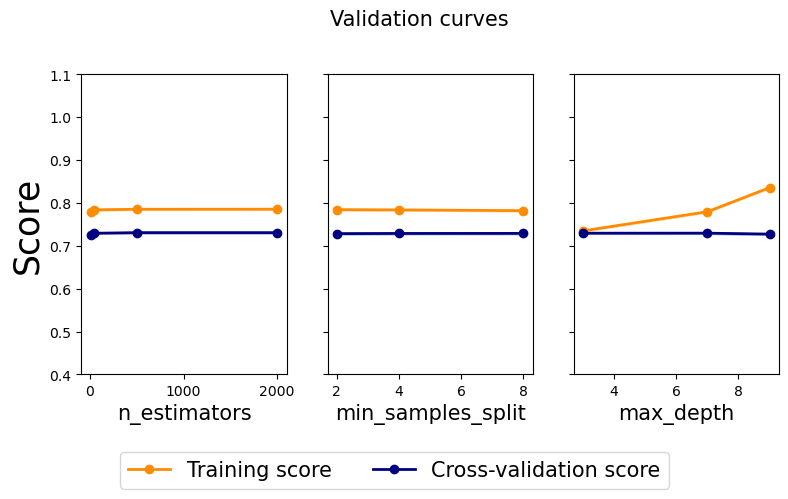

```python
# Plot CV Accuracy vs. n_estimators w/ learning_rate curves
plot_grid_search(cv_results=pd.DataFrame(grid_result.cv_results_),
                grid_params=grid)
```

```
Accuracy: = 71.457
```

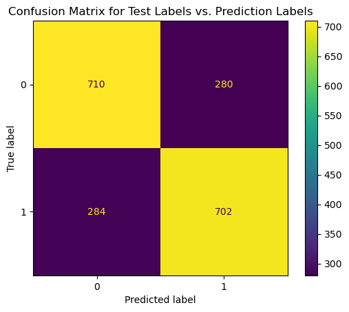

```python
# Construct model on tuned hyperparameters
rf_params = grid_result.best_params_

rf = RandomForestClassifier(n_estimators=rf_params['n_estimators'],
                            min_samples_split=rf_params['min_samples_split'],
                            max_depth=rf_params['max_depth'])

# Fit tuned model to training
rf.fit(X_train, y_train)

# Validate our tuned model on the test set
y_pred = rf.predict(X_test)

# Get test accuracy of tuned model
rf_acc = summarize_performance(y_pred, rf)
model_dict['Random Forest Classifier'] = rf_acc
plt.title("Confusion Matrix for Test Labels vs. Prediction Labels")
plt.show()
```

## Multi-Layer Perceptron Neural Network

We use a two-layer perceptron to see if we can obtain an improved mapping for purely accuracy and prediction purposes, which contrasts the ensemble-based methods above. Using a neural network could give me a better picture of the overall dataset when combined with the three other models discussed. Additionally, the neural network could help confirm suspicion on the detrimental correlation characteristic of our dataset.

```python
# MLP Specific API Helper Function
es = EarlyStopping(monitor='val_loss',
                   mode='min',
                   verbose=0,
                   patience=10,
                   restore_best_weights=True)

# Define a two-layer MLP model
def twoLayerModel(input_shape, neurons1=50, neurons2=50, opt=Adam(learning_rate=0.01), activation='relu'):
    inputs = Input(shape=input_shape)
    flatten1 = Flatten()(inputs)
    dense1 = Dense(neurons1, activation=activation)(inputs)
    dense2 = Dense(neurons2, activation=activation)(dense1)
    outputs = Dense(1, activation='sigmoid')(dense2)
    model = Model(inputs, outputs)
    model.compile(optimizer=opt, loss='binary_crossentropy', metrics=['accuracy'])

    return model

# Define validation method for models
def validateModel(model, X, y, n_folds=5):
    scores = []
    histories = []
    # prepare cross validation
    kfold = KFold(n_folds, shuffle=True, random_state=1)
	# enumerate splits
    for train_ix, test_ix in kfold.split(X):
        # select rows for train and test
        trainX, trainY, testX, testY = X[train_ix], y[train_ix], X[test_ix], y[test_ix]
        # fit model
        history = model.fit(trainX, trainY, epochs=10, batch_size=32, validation_data=(testX, testY), verbose=0, callbacks=[es])
        # evaluate model
        _, acc = model.evaluate(testX, testY, verbose=0)
        # print('> %.3f' % (acc * 100.0))
        # append scores
        scores.append(acc)
        histories.append(history)
    return scores, histories

# Plot diagnostic learning curves
def summarize_diagnostics(history, isList=False):
    if isList:
        for i in range(len(history)):
            # plot loss
            plt.subplot(211)
            plt.title('Cross Entropy Loss')
            plt.plot(history[i].history['loss'], color='blue', label='train')
            plt.plot(history[i].history['val_loss'], color='orange', label='test')
            # plot accuracy
            plt.subplot(212)
            plt.title('Classification Accuracy')
            plt.plot(history[i].history['accuracy'], color='blue', label='train')
            plt.plot(history[i].history['val_accuracy'], color='orange', label='test')
        plt.show()
        return

    fig, ax = plt.subplots(1,2, figsize=(12, 5))
    # Otherwise plot for just one history
    # plot loss
    ax[0].set_title('Loss Curves', fontsize=20)
    ax[0].plot(history.history['loss'], label='train')
    ax[0].plot(history.history['val_loss'], label='test')
    ax[0].set_xlabel('Epochs', fontsize=15)
    ax[0].set_ylabel('Loss', fontsize=15)
    ax[0].legend(fontsize=15)
    # plot accuracy
    ax[1].set_title('Classification Accuracy', fontsize=20)
    ax[1].plot(history.history['accuracy'], label='train')
    ax[1].plot(history.history['val_accuracy'], label='test')
    ax[1].set_xlabel('Epochs', fontsize=15)
    ax[1].set_ylabel('Accuracy', fontsize=15)
    ax[1].legend(fontsize=15)

# Summarize scores
def summarize_performance_nn(scores):
    # print summary
    print('Accuracy: mean=%.3f std=%.3f, n=%d' % (np.mean(scores)*100, np.std(scores)*100, len(scores)))
    # box and whisker plots of results
    plt.boxplot(scores)
    plt.show()
```

```python
# Prepare neural network
input_shape = X_train.columns.shape

# define model
opt = Adam(learning_rate=0.01)
model = twoLayerModel(input_shape, neurons1=128, neurons2=64, opt=opt)
# Print model summary
model.summary()
# fit model
history = model.fit(X_train, y_train, epochs=25, batch_size=64, validation_data=(X_test, y_test), verbose=1)
# evaluate model
_, mlp_acc = model.evaluate(X_test, y_test, verbose=1)
model_dict['Two-Layer Neurel Network'] = mlp_acc * 100.0
print('> %.3f' % (mlp_acc * 100.0))
```

[output not shown]

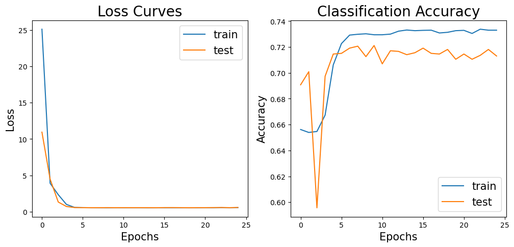

```python
# loss curves & accuracy
summarize_diagnostics(history)
```

## Can We Do Better?

```python
# Let's calculate the difference of values b/w Blue and red teams in all the columns

cols=[x[4:] for x in df.columns if "blue" in x and x[4:]!= 'Wins']

# Cols to dropp, already representing difference
cols_to_drop=['GoldDiff', 'ExperienceDiff']

final_cols=[x for x in cols if x not in cols_to_drop]

data_new=pd.DataFrame()

for col in final_cols:
    data_new[f'Diff_{col}'] =df[f'blue{col}']-df[f'red{col}']

# Keeping values corresponding to only Red in ['GoldDiff', 'ExperienceDiff'] i.e redGoldDiff and redExperienceDiff
for col_ in cols_to_drop:
    data_new[col_]=df[f'red{col_}']

# Now split the dataset into train and test
X_new=data_new

y_new=df['blueWins']

# Replace current X_train, X_test, y_train, y_test
X_train, X_test, y_train, y_test = train_test_split(X_new, y_new, test_size=0.2, random_state=1, stratify=y)
```

### Dimensionality Reduction with PCA

In this section, I will apply supervised PCA for prediction We want to see if we can improve accuracy by reducing the number of dimensions before we move onto the feature selection section.

```python
pca = PCA()

X_train_pca = pca.fit_transform(X_train)
X_test_pca = pca.transform(X_test)

# We will first use random forest as our classifier w/ the tuned hyperparameters
pca_rf = RandomForestClassifier(n_estimators=rf_params['n_estimators'],
                            min_samples_split=rf_params['min_samples_split'],
                            max_depth=rf_params['max_depth'],
                            random_state=1)

pca_rf.fit(X_train_pca, y_train)

# Predicting the Test set results
y_pred = pca_rf.predict(X_test_pca)

pca_rf_acc = summarize_performance(y_pred, pca_rf, display_matrix=False)
model_dict['PCA w/ Random Forest Classifier'] = pca_rf_acc
```

```
Accuracy: = 72.318
```

### Feature Selection

```python
classifier = RandomForestClassifier(n_estimators=rf_params['n_estimators'],
                            min_samples_split=rf_params['min_samples_split'],
                            max_depth=rf_params['max_depth'],
                            random_state=1)

sel_model = SelectFromModel(estimator=classifier)

sel_model.fit(X_train, y_train)

print("Total number of features in the database: ", len(X_train.columns))
print("Total number of features after removing according to RF feature importances: ", sel_model.get_support().sum())
print("Total features removed: ", int(len(X_train.columns)-sel_model.get_support().sum()))

# Display the features by retrieving the dataset before normalization
# feat_data = df.drop(['gameId', 'blueWins'], axis=1)
feature_idx = sel_model.get_support()
feature_name = X_new.columns[feature_idx]
print("Features selected: " + str(list(feature_name)))
```

```
Total number of features in the database:  19
Total number of features after removing according to RF feature importances:  7
Total features removed:  12
Features selected: ['Diff_Kills', 'Diff_Deaths', 'Diff_TotalGold', 'Diff_TotalExperience', 'Diff_GoldPerMin', 'GoldDiff', 'ExperienceDiff']
```

```python
# Transform model according to the features selected
X_train_rfc = sel_model.transform(X_train)
X_test_rfc = sel_model.transform(X_test)

# Predict
classifier.fit(X_train_rfc, y_train)

# Predicting the Test set results
y_pred = classifier.predict(X_test_rfc)

sel_rf_acc = summarize_performance(y_pred, classifier, display_matrix=False)
model_dict['Feature Selection w/ Random Forest Classifier'] = sel_rf_acc
```

```
Accuracy: = 71.255
```

```python
## Neural Network with selected features
# Prepare neural network
input_shape = X_train_rfc[0].shape

# define model
opt = Adam(learning_rate=0.01)
model = twoLayerModel(input_shape, neurons1=128, neurons2=64, opt=opt)
# Print model summary
model.summary()
# fit model
history = model.fit(X_train_rfc, y_train, epochs=25, batch_size=64, validation_data=(X_test_rfc, y_test), verbose=1)
# evaluate model
_, sel_nn_acc = model.evaluate(X_test_rfc, y_test, verbose=1)
model_dict['Feature Selection w/ Two-Layer Neurel Network'] = sel_nn_acc * 100.0
print('> %.3f' % (sel_nn_acc * 100.0))
```

```
Model: "model_9"
_________________________________________________________________
Layer (type)                 Output Shape              Param #
=================================================================
input_10 (InputLayer)        [(None, 7)]               0
_________________________________________________________________
dense_27 (Dense)             (None, 128)               1024
_________________________________________________________________
dense_28 (Dense)             (None, 64)                8256
_________________________________________________________________
dense_29 (Dense)             (None, 1)                 65
=================================================================
Total params: 9,345
Trainable params: 9,345
Non-trainable params: 0
_________________________________________________________________
> 71.407
```

## Reflection: Summarize Findings

### Model Accuracy

```python
for model in model_dict:
    print(f'model: {model} - accuracy: {model_dict[model]} %')
```

```
model: Logistic Regression - accuracy: 71.45748987854252 %
model: Gradient Boosting Classifier - accuracy: 72.31781376518218 %
model: Random Forest Classifier - accuracy: 71.45748987854252 %
model: Two-Layer Neurel Network - accuracy: 71.30566835403442 %
model: PCA w/ Random Forest Classifier - accuracy: 72.31781376518218 %
model: Feature Selection w/ Random Forest Classifier - accuracy: 71.25506072874494 %
model: Feature Selection w/ Two-Layer Neurel Network - accuracy: 71.40688300132751 %
```

### Feature Importance

```python
full_feature_name = list(df.drop(['gameId', 'blueWins'], axis=1).columns)
feat_sel_name = list(feature_name)

def get_feature_importance_names(f, feat):
    x = list(zip(f, feat))
    x.sort(reverse = True, key = lambda e: e[0])
    return [e[1] for e in x]

print("MOST IMPORTANT FEATURES ORDERED")
print(f"{'GRADIENT BOOSTING':<30}{'RANDOM FOREST':<30}{'PCA w/ RANDOM FOREST':<30}{'FEATURE SELECT w/ RANDOM FOREST':<30}")
print("\n".join(map(lambda e: f"{e[0]:<30}{e[1]:<30}{e[2]:<30}{e[3]:<30}",
    zip(get_feature_importance_names(gboost.feature_importances_, full_feature_name),
        get_feature_importance_names(rf.feature_importances_, full_feature_name),
        get_feature_importance_names(pca_rf.feature_importances_, full_feature_name),
        get_feature_importance_names(classifier.feature_importances_, feat_sel_name)))))
```

```
MOST IMPORTANT FEATURES ORDERED
GRADIENT BOOSTING             RANDOM FOREST                 PCA w/ RANDOM FOREST          FEATURE SELECT w/ RANDOM FOREST
redGoldDiff                   blueGoldDiff                  blueWardsPlaced               Diff_TotalGold
blueGoldDiff                  redGoldDiff                   blueGoldPerMin                GoldDiff
blueExperienceDiff            blueExperienceDiff            blueTowersDestroyed           Diff_GoldPerMin
redExperienceDiff             redExperienceDiff             blueTotalJungleMinionsKilled  ExperienceDiff
redDragons                    blueGoldPerMin                blueGoldDiff                  Diff_TotalExperience
blueDragons                   redTotalGold                  blueAvgLevel                  Diff_Deaths
redEliteMonsters              redGoldPerMin                 blueDragons                   Diff_Kills
```

```python
# Logistic Regression:
coef_data = np.concatenate((lr.coef_, np.exp(lr.coef_)),axis=0)
coef_df = pd.DataFrame(data=coef_data, columns=full_feature_name).T.reset_index().rename(columns={'index': 'Var', 0: 'coef', 1: 'oddRatio'})
coef_df.sort_values(by='coef', ascending=False)
```

|  | Var | coef | oddRatio |
| --- | --- | --- | --- |
| 15 | blueGoldDiff | 2.135233e-04 | 1.000214 |
| 16 | blueExperienceDiff | 1.083787e-04 | 1.000108 |
| 12 | blueTotalExperience | 8.032572e-08 | 1.000000 |
| 10 | blueTotalGold | 6.598734e-08 | 1.000000 |
| 20 | redWardsDestroyed | 0.000000e+00 | 1.000000 |
| 22 | redKills | 0.000000e+00 | 1.000000 |
| 23 | redDeaths | 0.000000e+00 | 1.000000 |
| 24 | redAssists | 0.000000e+00 | 1.000000 |
| 25 | redEliteMonsters | 0.000000e+00 | 1.000000 |
| 26 | redDragons | 0.000000e+00 | 1.000000 |
| 0 | blueWardsPlaced | 0.000000e+00 | 1.000000 |
| 27 | redHeralds | 0.000000e+00 | 1.000000 |
| 28 | redTowersDestroyed | 0.000000e+00 | 1.000000 |
| 29 | redTotalGold | 0.000000e+00 | 1.000000 |
| 30 | redAvgLevel | 0.000000e+00 | 1.000000 |
| 31 | redTotalExperience | 0.000000e+00 | 1.000000 |
| 32 | redTotalMinionsKilled | 0.000000e+00 | 1.000000 |
| 33 | redTotalJungleMinionsKilled | 0.000000e+00 | 1.000000 |
| 36 | redCSPerMin | 0.000000e+00 | 1.000000 |
| 21 | redFirstBlood | 0.000000e+00 | 1.000000 |
| 19 | redWardsPlaced | 0.000000e+00 | 1.000000 |
| 1 | blueWardsDestroyed | 0.000000e+00 | 1.000000 |
| 18 | blueGoldPerMin | 0.000000e+00 | 1.000000 |
| 2 | blueFirstBlood | 0.000000e+00 | 1.000000 |
| 3 | blueKills | 0.000000e+00 | 1.000000 |
| 4 | blueDeaths | 0.000000e+00 | 1.000000 |
| 5 | blueAssists | 0.000000e+00 | 1.000000 |
| 6 | blueEliteMonsters | 0.000000e+00 | 1.000000 |
| 7 | blueDragons | 0.000000e+00 | 1.000000 |
| 8 | blueHeralds | 0.000000e+00 | 1.000000 |
| 9 | blueTowersDestroyed | 0.000000e+00 | 1.000000 |
| 11 | blueAvgLevel | 0.000000e+00 | 1.000000 |
| 13 | blueTotalMinionsKilled | 0.000000e+00 | 1.000000 |
| 14 | blueTotalJungleMinionsKilled | 0.000000e+00 | 1.000000 |
| 17 | blueCSPerMin | 0.000000e+00 | 1.000000 |
| 37 | redGoldPerMin | 0.000000e+00 | 1.000000 |
| 35 | redExperienceDiff | -1.083787e-04 | 0.999892 |
| 34 | redGoldDiff | -2.135233e-04 | 0.999786 |

## Conclusions

Our various models, after some preparation and hyperparameter tuning, have all reached accuracy of above 70% correct classification. All of the models, however, performed relatively the same. The models could not achieve any performance greater than 75%, despite the dataset being quite large and the diverse classes my chosen models. **What could be some considerations that are influencing this trajectory of our models?**

- A team's gold lead is usually affected by experience
- Neutral objectives, such as towers and dragons, will yield both experience and gold
- Minion score influences experience and gold

We see that these correlations are detrimental to our models' performance.

#### **How could we improve the performance of our models?**

This dataset, although very rich with game information, is still missing a very important game mechanic: the specific champions. It is still the case that champions are changed frequently, at least more so than the overall system of the game. However, including champion information to the dataset will allow us to analyze a team's overall champion composition, which will provide additional layers of analysis for our models to learn. A very simple example of new information is champion scalability; different champions get stronger and weaker at different stages of the game, so a team with champion compositions leaning toward a strong late-game could be winning more games despite losing within the first 10 minutes! The inclusion of champion specifications (subsequently, the duration of a specific match) could potentially increase our model's accuracies.

Introducing all the champions (of which, there 100+) could definitely improve performance, but it has the cost of introducing significant complexities to data preparation and model training. Despite the lack of these additional details, it is important to re-iterate that, for the sake of longevity, using the current data can still be useful under some considerations. Being able to predict a little over 70% of a match's outcome within the first 10 minute of a game is quite an amazing feat.

#### **For the Players**

As we have examined from the feature importance, gold difference is definitely the most significant to determining a game's winner - even in the earliest of early-game. Almost in all situations, gaining gold yields experience, another important feature. Other features, such as neutral objectives, are not worth sacrificing players. For example, if a player dies trying to save a tower, the enemy team gets gold, experience, and map pressure (an intuitive variable that is not easily quantifiable), and the dead player waiting to respawn will not be able to gain gold nor experience.

Early game is important, as we can see from the ~70% accuracy, so how a team players in the beginning is a huge determining factor. Start the game strong with a good mental fortitude1